# Collateral Phone Survey Report

Sarv Salvi

November 30, 2017

### Summary of Research on Collateral and Collateral Policy Changes

A few reports produced in LR 2016 and LR 2017 have indicated that collateral may be affecting the Kenya program through a number of different channels.

1. 2017 Enrollment Report: 45% of non-enrollees claimed that fear of loosing collateral was a major reason for their decision not to re-enroll. Fear of having to sell collateral was also a major concern for 33% of those who did enroll. From these findings an important question for future growth is whether fear of loosing collateral is based on actual experience of clients with One Acre Fund or is it part of a more general fear of loans.
2. 2016 Repayment Report: This report summarizes survey data on collateral that suggest that some clients are pressured to sell collateral. For example, 26% of clients claimed their GL had threatened to take collateral and 28% claimed their FO had threatened to take collateral. This suggests that collateral may be an important client protection issue.

During the Long Rains 2016 season we tried to distance ourselves from collateral by forbidding FOs from asking clients to sell collateral or be present when it is sold. There were also no trainings for groups on collateral. Early in the Long Rains 2017 focus groups were asked for their opinions and experience with collateral. From those discussions we discovered that clients generally positive opinions about collateral. They felt that being able to collect collateral was an important way to prevent group banning. Based on those focus groups we created a collatral agreement form for groups to use and a training that gave best practices on using collateral. However, FOs are still not allowed to be involved in anything related to collateral including the creation of the agreements.

### Definition of Collateral

In the formal banking system collateral is defined as any asset pledged to guarantee repayment of a loan or sold in order to repay a loan.

### Scale of Collateral Usage

The scale of collateral usage is described in two ways:

1. Proportion of clients who have to sell collateral or create collateral agreements.
2. Portion of total transaction being paid for with collateral.

#### Frequency Of Collateral Selling and Collateral Agreement Creation

Roughly, 1 in 8 clients claimed to have sold collateral to repay their loans. This means that on average there is one person in each group who will have to sell collateral.

Scale of Collateral Selling in Kenya Program

| Collateral Sold | Number of Clients in Sample | Percent |
| --- | --- | --- |
| Yes | 267 | 12.39 |
| No | 1888 | 87.61 |

CI for % Selling Collateral: (0.1100, 0.1383) at 95%.

The table below shows that just under 40% of clients are in a group that had some sort of collateral agreement in Long Rains 2017. Please note that this statistic makes no distinction between written or verbal collateral agreements.

Scale of Collateral Agreement Creation in Kenya Program

| Collateral Agreement Created | Number of Clients in Sample | Percent |
| --- | --- | --- |
| Yes | 387 | 39.33 |
| No | 597 | 60.67 |

CI for % Creating Collateral Agreement: (0.3618, 0.4238) at 95%.

#### Sizing Repayment Activity Financed by Collateral

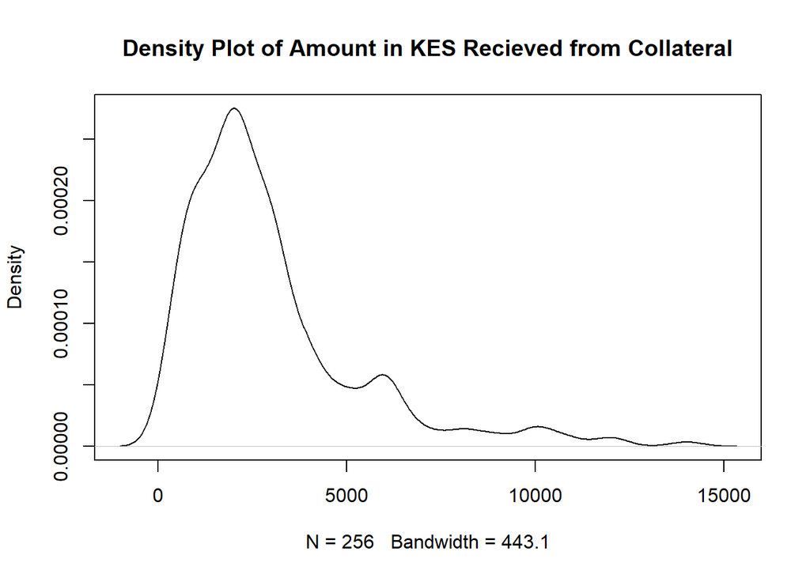

To get a better sense of the importance of collateral to repayment we can look at the value of the collateral relative to the total transaction size. The average percent of the total transaction that is repaid using collateral is 30.93% (SD: 21.14). The density plot below shows the distribution of this variable. This suggests that collateral sellers have a significant portion of their loan remaining when they decide to sell.

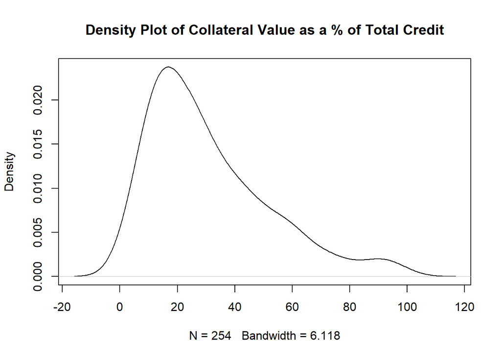

### Effect on Clients

#### Client Experience:

In the phone survey we asked two questions to understand client experience around collateral. The first was whether collateral was sold with the consent of the client. The second was the level of pressure to sell collateral that they experienced. These two measures were collected independently. For example it was possible for a collateral seller to have not been heavily pressured but still have their collateral sold without their consent. The tables below summarize the findings from these two questions.

From the table below we see that in the vast majority clients who sold collateral have either sold collateral voluntarily. Non-consensual collateral seizure is experienced by about 0.6% of the total country program which in LR 2017 was roughly 1500 clients. Similarly, the vast majority of clients never felt pressured to sell collateral. Just about 2% of the country program reported feeling some amount of pressure to sell collateral.

Proportion of Collateral Sold With Consent

| Consent Status | Number of Clients in Sample | Percent of Total Sample | Percent of Collateral Sellers |
| --- | --- | --- | --- |
| Yes | 254 | 11.79 | 95.13 |
| No | 13 | 0.60 | 4.87 |

Proportion of Collateral Sold under Various Pressure Levels

| Pressure Level | Number of Clients in Sample | Percent of Total Sample | Percent of Collateral Sellers |
| --- | --- | --- | --- |
| No Pressure | 224 | 10.39 | 83.90 |
| Some Pressure | 23 | 1.07 | 8.61 |
| Heavy Pressure | 20 | 0.93 | 7.49 |

#### Program Impact

Collateral selling can affect program impact at scale through a number of number of different mechanisms. Through the phone survey we were able to collect data on some of these mechanisms.

1. Type of Items Sold: As shown in the table below clients who sell collateral typically sell a portion of their maize harvest, livestock (chickens, cows, goats) or trees.

Type of Item Sold as Collateral

| Asset Category | Number of Clients in Sample | Percent of Total Sample | Percent of Collateral Sellers |
| --- | --- | --- | --- |
| Livestock | 103 | 4.78 | 38.58 |
| Portion of Maize Harvest | 104 | 4.83 | 38.95 |
| Trees | 44 | 2.04 | 16.48 |
| Other | 16 | 0.74 | 5.99 |

Selling a portion of the maize harvest at harvest time is a common practice. There may be more clients selling a portion of their harvest then the amount shown here. These only represent the number of clients selling some of their harvest specifically for the purpose of repaying their loan from OAF. Although we would prefer to have clients try to sell other goods that have a minimal direct effect on future income and food security but it is hard to imagine what those assets might be. These items seem to be the key stores of value for farmers that are also quite liquid and would not drastically change quality of life in the short term.

2. Receiving an Unfair Price: A significant number of collateral sellers claimed to have received an unfair value for their collateral. This was reported by clients who sold collateral voluntarily as well those who were pressured or forced to sell. This suggests that simply having to sell an asset exposes clients to the risk of receiving an unfair value. The time pressure from the repayment deadline and the depressed prices of maize during the harvest period may also add to this problem.

Received Fair Value

| Fair value | Number of Clients in Sample | Percent of Total Sample | Percent of Collateral Sellers |
| --- | --- | --- | --- |
| Yes | 210 | 9.74 | 78.65 |
| No | 57 | 2.65 | 21.35 |

Among clients that report receiving an unfair value for their collateral on average difference between the value they received and the amount they think is fair is 1622.28 KES.

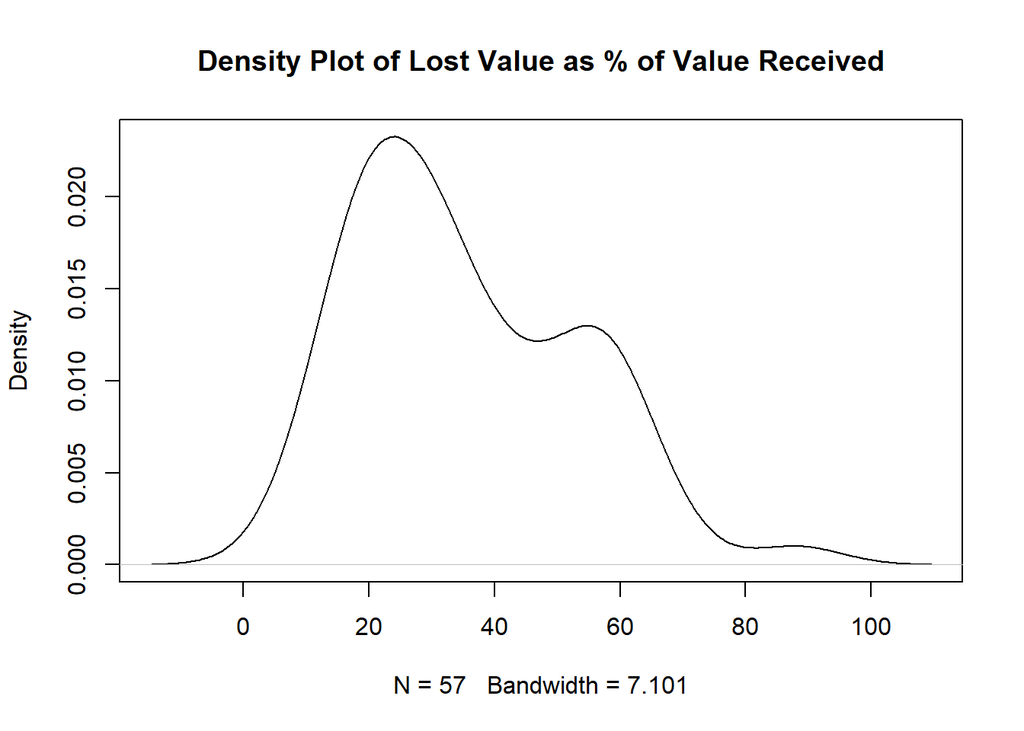

On average the lost value was 35.38% of the value they received.

3. Selling assets with large differential between Asset Value and Remaining Loan Amount : This is problematic for farmers because they are loosing income producing assets because they do not have another asset that is closer to the value of the loan balance. In addition, it may not be possible to reinvest the differential and produce a proportional amount of income. Below we look at how closely the actual amount loan amount paid off by selling the asset matched the selling price.

Value of Collateral Relative to Remaining Loan

| Collateral Value Relative to Loan Balance | Number in Sample | Percent of Total Sample | Percent of Collateral Sellers |
| --- | --- | --- | --- |
| More | 66 | 3.06 | 24.72 |
| Same | 98 | 4.55 | 36.70 |
| Less | 101 | 4.69 | 37.83 |

On average clients claim a difference of 1792.02 KES between the value they got for the piece of collateral they sold and the amount that they had remaining on their loan.

4. Net Benefit to Retention: Allowing collateral selling could be resulting in a net increase in retention. Below are some statistics that provide support to a couple mechanisms for this. However, knowing the size of the effect of each of these mechanisms with precision or proving a causal relationship would require further investigation.

Effect on Group of Banning: If 12.38% of clients have to sell collateral that is about equal to 1 person in each group. Even if collateral sellers tend to be in groups with other collateral sellers it is easy to see that selling collateral selling is very beneficial in decreasing the number of banned clients.

Effect on Retention of Respondent: The first of the two regressions below models the effect of having to sell collateral under any circumstances on re-enrollment. What we see is that collateral sellers as a whole are only 4% less likely to re-enroll. This result is statistically significant. However, in the next regression we break this result down further by looking at likelihood of re-enrollment across clients who had collateral sold without their consent or who were pressured to sell. The results from this regression are intuitive. Clients who have collateral sold without consent are 41% less likely to re-enroll. This result is also very statistically significant. Meanwhile, feeling pressured to sell collateral seems to have only a mildly negative effect on probability of re-enrollment and more importantly the result is not statistically significant. This means that those who are pressured do not appear to be less likely to re-enroll than those who sell completely voluntarily or those that do not sell collateral at all . These results suggest that the negative effect of selling collateral on re-enrollment is due almost entirely to the low probability of re-enrollment among those that had collateral sold without consent.

**Effect of Selling Collateral on Re-enrollment in LR 2018**

|  | *Dependent variable:* |
| --- | --- |
|  | Enrollment_Indicator |
| form.Collateral_Group_Repayment_Questions.Collateral_Sold | -0.420** |
|  | (0.207) |
| Constant | 2.186*** |
|  | (0.112) |
| Observations | 1,138 |
| Log Likelihood | -396.145 |
| Akaike Inf. Crit. | 796.291 |
| *Note:* | p<0.1; p<0.05; p<0.01 |

**Effect of Level of Coercion to Sell Collateral on Re-enrollment in LR 2018**

|  | *Dependent variable:* |
| --- | --- |
|  | Enrollment_Indicator |
| OnlyPressure | -0.465 |
|  | (0.534) |
| form.Collateral_Group_Repayment_Questions.No_Consent | -2.420*** |
|  | (0.775) |
| Constant | 2.074*** |
|  | (0.212) |
| Observations | 267 |
| Log Likelihood | -99.910 |
| Akaike Inf. Crit. | 205.820 |
| *Note:* | p<0.1; p<0.05; p<0.01 |

Unmeasured Costs of Selling Collateral: All costs types listed below have no direct evidence from the phone survey that support their importance but are worth being acknowledged.

1. Lost future value appreciation from an asset: This is may be especially important for trees and livestock.
2. Selling at low point in yearly market price cycle: This is especially true for maize harvest sold at harvest time.

### Learnings

This section summarizes key insights from previous sections and combines them with additional data points from the phone survey. They are organized by thematic groups.

Unanticipated Expenses Among Collateral Sellers

| Unanticipated Expenses | Number in Sample | Percent of Collateral Sellers |
| --- | --- | --- |
| Yes | 98 | 36.7 |
| No | 169 | 63.3 |

4. Group Coverage and Collateral Selling
   - Group coverage and collateral selling are complementary: It appears that very few clients (2%) receive money from group members to make payments towards their loans and even fewer repay that amount by selling collateral.
   - Group Coverage is only possible for smaller amounts: The finding above does not suggest that group coverage is something that does not happen or that group members don’t lend any money to each other. It does suggest that it is not happening when the loan amounts remaining are above 1000 KES. When asked why they could not borrow from their group to cover their loan the majority said that their group members either did not have the cash to cover them or believed that they would be unable to repay them. In a cash strapped environments amounts this large can only be paid off in a reasonable time frame with collateral in which case farmers are correct to cut to the chase and expect each other to sell collateral.

Clients who were Covered by Group Member(s)

| Covered by Group | Number of Clients in Sample | Percent of Total Sample |
| --- | --- | --- |
| Yes | 39 | 1.81 |
| No | 2116 | 98.19 |

Clients Repaying Group Coverage with Collateral

| Repaid with Collateral | Number of Clients in Sample | Percent of Total Sample | Percent of Collateral Sellers |
| --- | --- | --- | --- |
| Yes | 8 | 0.37 | 3.00 |
| No | 31 | 1.44 | 11.61 |

5. Financial Planning:
   - Collateral Selling is not a planned Strategy: Most clients don’t plan on using collateral to repay their loan. This was shown by the similar percentages of collateral sellers and non-sellers who claimed they had anticipated at the start of the season that they would have to use collateral to repay their loan. Survey data on this is summarized below.
   - Collateral Sellers do not have strong estimates of cash flows: The majority of seller could not point to an unanticipated expense during the season and they had not anticipated having to use collateral to repay their loan at the start of the season. This suggests that collateral sellers do not have robust estimates for their cash flows over the course of the year. This can be related to an unstable secondary source of income. This must affect how well they are able to select a loan size that is appropriate for them.

Anticipation of Collateral Selling Among those that Sold Collateral

| Anticpated Selling Collateral | Number in Sample | Percent of Collateral Sellers |
| --- | --- | --- |
| Yes | 45 | 16.85 |
| No | 222 | 83.15 |

Anticipation of Collateral Selling Among those that Did Not Sell Collateral

| Anticpated Selling Collateral | Number in Sample | Percent of Non-Sellers |
| --- | --- | --- |
| Yes | 177 | 20.32147 |
| No | 694 | 79.67853 |

6. GLs are primarily responsible for pressuring clients to sell collateral and enforcing the decision to sell collateral.

Collateral Seller Claiming Pressure from FO

| Pressured by FO | Number of Clients in Sample | Percent of Collateral Sellers with Negative Experiences |
| --- | --- | --- |
| Yes | 25 | 58.14 |

Collateral Seller Claiming Pressure from GL

| Pressured by GL | Number of Clients in Sample | Percent of Collateral Sellers with Negative Experiences |
| --- | --- | --- |
| Yes | 31 | 72.09 |

7. Collateral is usually sold towards the end of the season around harvest time

Time in Year that Collateral Was Sold

| Time Period | Number of Clients in Sample | Percent of Collateral Sellers |
| --- | --- | --- |
| Before Qualifiers Deadline | 2 | 0.75 |
| After Qualifers Before Input Delivery | 4 | 1.50 |
| After Input Delivery Before Harvest | 114 | 42.70 |
| After Harvest | 147 | 55.06 |

Note: Because of the way answers choices were constructed the the second most common time period (input-harvest) represents a very large period of time. In future surveys it would be best to ask for the month. It might be possible to get a more precise answer by plotting the vertical repayment data over time for collateral sellers in this data set.

### Recommendations

This section suggest potential changes that can be implemented this year to reduce the negative effects of selling collateral on client experience and program impact.

1. Retraining GLs on collateral agreements and best practices around harvest time could help improve client experience by reinforcing concepts when they are most relevant.
2. Set and communicate repercussions for GLs who are taking collateral without consent.

Currently, the Case Investigations team that handles these cases only have guidelines for disciplinary action that can be taken against FOs. Since GLs are not our employees we are limited in the types of action we can take against them if we find that they are harassing their groups members. However, it may be possible to ban that individual from the coming season or prevent them from being a GL in the following season.

3. Improving Information on Collateral Related Harassment:
   - Increasing Self-Reported Cases of Harassment: This might be something that is already being discussed. It seems that only a small fraction of the people who experience some sort of harassment are able to file a case with CE. There could be a number of reasons for this. Farmers may be unaware of the CE hotline number, they could be unaware of the types of behavior that ought to be reported or perhaps there is a bottle-neck in CE.
   - Tracking Collateral Related Harassment Calls: Currently CE lumps in all calls related to collateral into a bucket containing all harassment cases. Specific types of issues can be tracked by introducing additional tags in Zendesk and training CE call center staff to identify when to use that tag. This would allow us to track the fraction of cases in a given year that are reported and addressed.
4. Reducing Negative Effect on Program Impact for Collateral Seller
   - Stress that collateral items should be less than outstanding loan: Clients can reduce the negative impact of selling collateral by purposefully selling an asset that is lower than the outstanding amount and then paying the remaining portion in cash or having group members cover the smaller outstanding amount.
   - Stress a combined group coverage and collateral approach: if we can have groups commit to collectively cover up to 1000 KES of anyone’s outstanding loan we can significantly reduce the program impact lost in selling collateral. This can be something that is included in the collateral agreement form.
   - Avoid pledging portion of the maize harvest: GLs should be trained to suggest not selling a portion of their maize harvest to repay their loan since maize prices will be quite low at the time of harvest. Instead they could sell another asset like livestock or trees that might have more consistent valuations over the course of a year. This can be discussed again in conjunction with the training on saving 3 bags for 3 months.
   - Narrowing Bands in Collateral Form: The bands in the collateral agreement form can be narrowed and limited to the range of 1000 - 4000 KES which are the most common amounts covered by collateral. This may reduce the discrepancy between collateral value and outstanding amount.

### Topics for Futher Investigation

This section considers longer term activities to improve client experience around collateral while balancing the beneficial effects on retention.

1. Incentives for Customer Service for FO: Right now our incentive structure pushes GLs and FOs to achieve repayment at risk of harassing their clients. Incentivizing FOs based on some customer service metric could help equalize the weight put on both.
2. Financial Planning Training: Since most collateral sellers cannot point to a unanticipated expense, did not anticipate having to sell collateral and have a mix of transaction sizes often well below the credit limits it is possible that they could benefit from support on choosing loan sizes that are more conservative and planning out payments based on cash flows.
3. Relationship Between Payment Trajectory and Collateral: Given the significant value of collateral relative to transaction size it appears that these clients have a significant portion of their loan remaining late in the season. Perhaps identifying areas with large number of these clients can help us target training on collateral best practices.
4. Revisiting a Restructured Emergency Loan or Loan Extension Product:  
   Program Innovations recently trialed an Emergency Loan. A similar product targeting clients who might otherwise sell collateral could help minimize the negative impact of voluntary collateral selling on impact. In the trial the loan was for only 500 KES and the deadline for repayment was the same as for their main loan. A emergency loan of a larger size or fee for an extension on the current loan could help some clients avoid having to sell collateral. In particular, those that had to sell a portion of their maize harvest to repay their loan might be able to wait till market prices are higher.
5. Revisiting Alternative Liability Structures: The most negative client experiences around collateral are probably occurring because of the pressures exerted by group liability. A trial on individual liability (IL) by Program Innovations concluded that individual liability would only be beneficial to the sustainability of the program if default rate was significantly lower than it is now. Given that IL was not successful perhaps it would be worth brainstorming different liability structures that combine some of the benefits of group liability towards retention and repayment with the client protection benefits of IL.
6. Fluctuations in Livestock and Tree Market: One Acre Fund could expend some resources in tracking the fluctuations in these common collateral items over the course of 1 year to make accurate suggestions to farmers on whether they should sell a portion of the maize harvest or try one of these common collateral items.
7. Investigating Relationship between Quality of Collateral Agreement and Retention: Regressions using the phone survey data did not identify a statistically significant positive relationship between creation of a collateral agreement and retention or coerced collateral seizure. However, information was collected that could be used to measure the quality of a collateral agreement. These included whether the agreement was written or verbal, whether different items were pledged for different outstanding loan amounts, whether the collateral form was used, and the number number of times the agreement was revisited over the year. Identifying a relationship between the quality of the agreement and client retention would involve first specifying a methodology for combining these different variables either as a part of a single variable or within a regression model. This would be time-consuming and somewhat arbitrary so it has been left as a topic for future investigation.

### Data and Survey Methodology

#### Sampling Methodology:

Sampling was done randomly, stratified on district and proportional to the number of clients in each district. However, the number of surveys completed for clients in each district were not in proportion to the number of clients in that district. This could affect how well this sample represents the country program. The table below was constructed in order to give a sense of which districts were over or under-represented in this sample.

Comparison between Intended and Actual Sampling by District

| District Name | % of All LR 2017 Clients | % of Phone Survey Sample | Difference |
| --- | --- | --- | --- |
| Alego | 4.091691 | 5.2900232 | -1.1983324 |
| Belgut | 1.102498 | 1.1136891 | -0.0111915 |
| Bungoma | 1.524758 | 1.4849188 | 0.0398393 |
| Busia | 3.916712 | 4.2691415 | -0.3524299 |
| Butere | 6.272728 | 6.1716937 | 0.1010343 |
| Cherangany | 1.711288 | 1.5313225 | 0.1799660 |
| Chwele | 2.726083 | 2.3201856 | 0.4058970 |
| Gem | 5.150978 | 4.9651972 | 0.1857812 |
| Green Shamba | 1.345073 | 1.1136891 | 0.2313837 |
| Gucha | 1.819100 | 1.5777262 | 0.2413735 |
| Hamisi | 3.446535 | 3.8051044 | -0.3585693 |
| Kabiyet | 1.124744 | 0.6496520 | 0.4750924 |
| Kabondo | 2.398799 | 1.5777262 | 0.8210725 |
| Kakamega (South) | 3.487606 | 2.6914153 | 0.7961907 |
| Kakamega B (North) | 5.122742 | 4.0835267 | 1.0392155 |
| Kimilili | 4.155436 | 3.8051044 | 0.3503319 |
| Kisii | 2.141250 | 2.0417633 | 0.0994864 |
| Lugari | 6.120851 | 8.2134571 | -2.0926059 |
| Masaba | 2.466395 | 3.1090487 | -0.6426542 |
| Matete | 4.181533 | 4.5011601 | -0.3196266 |
| Migori | 2.543830 | 1.9489559 | 0.5948745 |
| Nambale | 3.126952 | 3.5730858 | -0.4461339 |
| Ndalu | 3.885481 | 4.7795824 | -0.8941018 |
| Nyamira | 2.070659 | 1.5313225 | 0.5393366 |
| Rachuonyo | 2.375268 | 2.5058005 | -0.1305320 |
| Rongo | 2.796245 | 2.5058005 | 0.2904450 |
| Sirisia | 2.812930 | 2.5522042 | 0.2607263 |
| Suneka | 1.145708 | 0.8352668 | 0.3104408 |
| Teso | 4.145169 | 4.1299304 | 0.0152382 |
| Tinderet | 1.193624 | 1.0208817 | 0.1727421 |
| Vihiga | 3.794354 | 3.2018561 | 0.5924983 |
| Webuye | 5.802979 | 6.4965197 | -0.6935404 |

GLs were not surveyed. We believed their responses might be biased since they were supposed to have received a training on collateral best practices intended to guide their behavior.

Out of the 2221 surveys completed, 984 were completed using the first version of the survey where all questions were asked to all respondents. For the remaining 1237 surveys the survey halted if the respondent was not a collateral seller. The purpose of this change was to shorten the survey in order to achieve an adequate sample of collateral sellers.

#### Link to Data and Analysis Script:

Raw Data: (https://drive.google.com/drive/u/0/folders/1SyBQm4bSdiZefiigeMMKSloP1KNm2srL)

Cleaning and Analysis Script: (https://drive.google.com/drive/u/0/folders/1WDwf2YBQQrk6zRWmwl4ZIFlYig8igHBm)

#### Link to Survey Questions:

Version 1: (https://drive.google.com/drive/u/0/folders/1GYyKqFHcrFFKku3-ev5Zcrp-ja6LcMJG)

Version 2: (https://drive.google.com/drive/u/0/folders/1kr8WqPSMYlkDS-bFCXZ5kkPfAyVQ9ePV)

#### Referenced Documents

1. 2017 Collateral Memo
2. 2016 Enrollment Report
3. 2016 Non-Rejoiners Report